# Hedonic Pricing Models

##### Sawyer Benson’s Master Thesis

###### December 19, 2021

#### Current Progress on OLS Models & Methodology

Hey Yuki,

I wanted to send you an update on my progress with the Hedonic Pricing Model (i.e. HPM or OLS) portion of my thesis and figured this would be the best way to do it since I have so many methods and lines of code to share with you and notate on.

I have a section at the end (6) with questions and next steps, but the main thing I’m asking for here is your approval (or suggestions) about the current process. If you are satisfied with the way I analyzed the Corona subset, and the method used for the specific beta coefficient comparisons across the corona subset *(see results in section 5.3 for example of final statement)*, I will begin to complete the rest of the subsects in a similar way.

**Note:**

- The regressions make the document appear bigger than it actually is. This should take only a few minutes to review.
- Feel free to leave comments using the comment tool here on RPubs.

**Thanks!**

**Sawyer**

#### Outline of This Document

1. Update on data set dimensions
2. Base OLS model using data *including* outliers
3. Outlier-removal process
4. Base OLS model using data *excluding* outliers
5. Subset analysis
   - Test significance of corona dummy variable
   - Compare specific beta coefficient (e.g. number of bedrooms)
6. Questions for you and next steps

##### **1. Update on Dataset**

After cleaning the original data set of 5000 observations, I realized just how many observations are lost in the process of the first-stage cleaning (e.g. removing all #N/A) and how unbalanced the cleaned set was in terms of post and pre-corona observations.

So, I decided to do another, larger data pull with the following results:

- Location: Louisiana, USA
- Observations: 15,000
  - Pre-corona: 10,000
  - Post-corona: 5000
- Date Range: March 23, 2010 - December 15, 2021

##### **2. Base OLS: Including Outliers**

This model is just to see where we are in terms of data consistency and relevance.

```r
attach(data)
```

```r
summary(lm_raw)
```

```
Call:
lm(formula = sold_price ~ . - mls_number - school_high - school_junior -
    school_middle - roof_type_shingle_bi - sold_date - total_area -
    corona_crisis - post_corona_bi, data = data)

Residuals:
    Min      1Q  Median      3Q     Max
-661307  -37161    -573   33353 1746936

Coefficients:
                                       Estimate Std. Error t value Pr(>|t|)
(Intercept)                           1.176e+05  6.404e+04   1.837 0.066268 .
property_typeDUP                      4.597e+03  4.584e+04   0.100 0.920117
property_typeOTH                      1.204e+05  4.598e+04   2.617 0.008867 **
property_typePAT                      1.245e+04  1.635e+04   0.762 0.446193
property_typeSGL                      5.470e+04  5.654e+03   9.675  < 2e-16 ***
property_typeTNH                      2.772e+04  7.616e+03   3.639 0.000274 ***
air_conditioningnot_central          -2.581e+04  2.599e+03  -9.931  < 2e-16 ***
appartment_bi                        -1.226e+04  1.993e+04  -0.615 0.538653
patio_bi                              6.882e+03  1.489e+03   4.623 3.82e-06 ***
school_general                        2.611e+04  2.779e+03   9.397  < 2e-16 ***
photo_count                           1.473e+03  8.050e+01  18.299  < 2e-16 ***
pool_bi                               2.035e+04  2.365e+03   8.605  < 2e-16 ***
rear_yard_access_bi                  -4.922e+02  4.627e+03  -0.106 0.915277
roof_typeother                       -8.992e+02  2.498e+03  -0.360 0.718919
roof_typeshingle                      2.820e+04  2.820e+03   9.998  < 2e-16 ***
roof_typeslate                        1.236e+04  1.085e+04   1.139 0.254770
gas_typeNatural                      -8.737e+04  5.617e+04  -1.555 0.119877
gas_typeNone                         -9.020e+04  5.618e+04  -1.606 0.108370
gas_typePropane                      -2.815e+04  5.878e+04  -0.479 0.631982
out_building_livable_bi               4.749e+04  1.197e+04   3.969 7.25e-05 ***
out_building_not_livable_bi          -7.553e+03  1.571e+03  -4.807 1.55e-06 ***
living_area                           8.170e+01  1.736e+00  47.051  < 2e-16 ***
land_acres                           -3.619e-01  4.141e+00  -0.087 0.930370
appliances_included_bi                2.187e+04  1.978e+03  11.060  < 2e-16 ***
garage_bi                             1.108e+04  1.477e+03   7.500 6.74e-14 ***
conditionExcellent                    8.670e+04  8.505e+03  10.194  < 2e-16 ***
conditionFair                        -4.604e+04  1.211e+04  -3.803 0.000144 ***
conditionNew                          8.495e+04  1.211e+04   7.013 2.44e-12 ***
conditionOther                        2.756e+04  8.981e+03   3.069 0.002152 **
```

[output cut: 54 more lines]

```
city_limit_bi                         3.560e+04  4.433e+03   8.031 1.04e-15 ***
subdivision_bi                       -3.279e+03  2.783e+03  -1.178 0.238689
tennis_court_bi                      -8.952e+04  3.054e+04  -2.931 0.003379 **
termite_contractUnknown              -2.548e+04  6.732e+03  -3.785 0.000155 ***
termite_contractYes                   2.949e+04  4.851e+03   6.080 1.23e-09 ***
water_typeOther                      -2.110e+03  1.805e+04  -0.117 0.906958
water_typePublic                      1.103e+04  1.776e+04   0.621 0.534341
water_typeWell                        1.712e+04  1.904e+04   0.899 0.368461
waterfront_bi                         3.789e+04  2.583e+03  14.671  < 2e-16 ***
---
Signif. codes:  0 ‘***’ 0.001 ‘**’ 0.01 ‘*’ 0.05 ‘.’ 0.1 ‘ ’ 1

Residual standard error: 78740 on 14517 degrees of freedom
Multiple R-squared:  0.6486,    Adjusted R-squared:  0.6464
F-statistic: 294.5 on 91 and 14517 DF,  p-value: < 2.2e-16
```

```
not plotting observations with leverage one:
  12398
```

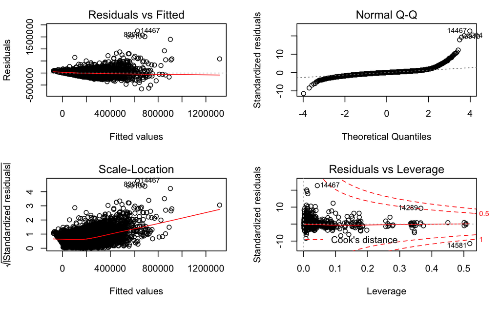

```r
par(mfrow = c(2,2))
plot(lm_raw)
```

##### **3. Outlier-Removal Process**

All variables subject to outliers are tested and outliers are removed.

All observations more than 1.5 standard deviations from the mean are considered outliers, except for in the case of ‘age,’ which is restricted to 3.5 standard deviations.

##### **3.1 Summary of Outlier Removal**

```r
table(data_no_outliers$corona_crisis)
```

[output not shown]

**Note:** Names of variables are on the left, data with outliers is on the left, and outliers removed are on the right.

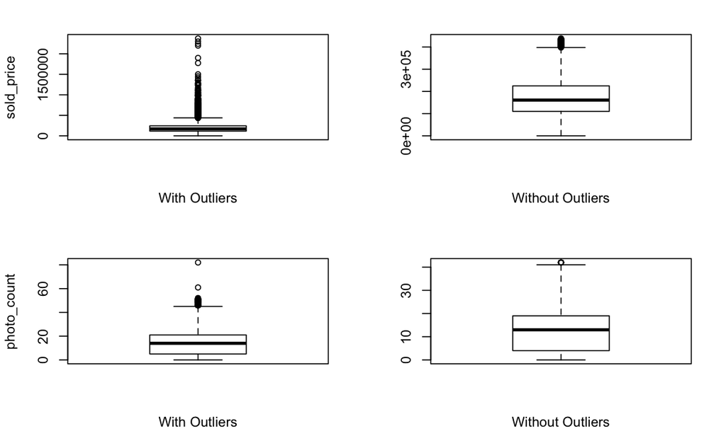

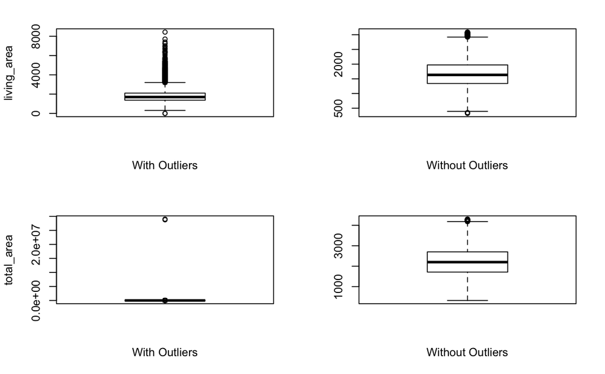

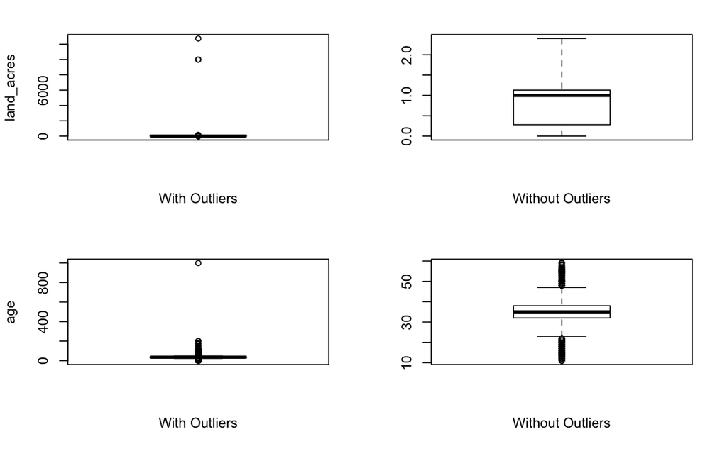

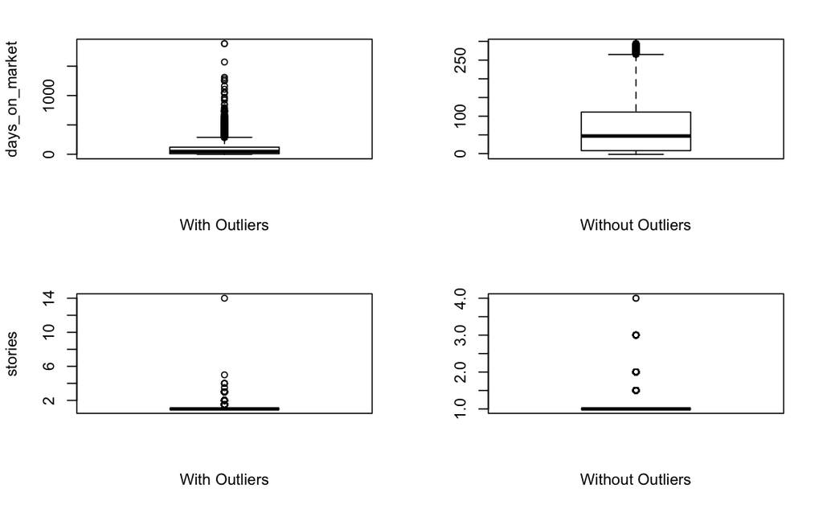

**Note:** the folloiwng variables’ outliers were delt with in Excel

- beds_total
- bath_full
- bath_half

##### **4. Base OLS: No Outliers**

We now can see the results of removing outliers on our most general model.

These differences are particulary clear when comparing the two groupings of four diagnostic plots at the end of this regression to see the reduction in both extreme residual values and high-leverage points.

```r
summary(lm_clean)
```

```
Call:
lm(formula = sold_price ~ . - mls_number - school_high - school_junior -
    school_middle - roof_type_shingle_bi - sold_date - total_area -
    corona_crisis - post_corona_bi, data = data_no_outliers)

Residuals:
    Min      1Q  Median      3Q     Max
-277056  -28678    -371   28506  277632

Coefficients:
                                   Estimate Std. Error t value Pr(>|t|)
(Intercept)                       1.384e+05  5.433e+04   2.548 0.010862 *
property_typeDUP                 -1.742e+04  2.853e+04  -0.611 0.541401
property_typeOTH                  1.060e+05  2.865e+04   3.699 0.000218 ***
property_typePAT                  3.921e+03  1.070e+04   0.367 0.713903
property_typeSGL                  2.976e+04  3.803e+03   7.824 5.57e-15 ***
property_typeTNH                  2.022e+04  4.995e+03   4.048 5.19e-05 ***
air_conditioningnot_central      -2.816e+04  1.807e+03 -15.583  < 2e-16 ***
appartment_bi                    -6.655e+03  2.108e+04  -0.316 0.752215
patio_bi                          8.603e+03  1.032e+03   8.340  < 2e-16 ***
school_general                    2.626e+04  1.980e+03  13.261  < 2e-16 ***
photo_count                       1.004e+03  6.061e+01  16.556  < 2e-16 ***
pool_bi                           1.142e+04  1.777e+03   6.426 1.36e-10 ***
rear_yard_access_bi              -1.209e+04  3.930e+03  -3.078 0.002090 **
roof_typeother                    2.178e+03  1.811e+03   1.203 0.229086
roof_typeshingle                  3.245e+04  2.057e+03  15.775  < 2e-16 ***
roof_typeslate                    2.030e+03  8.264e+03   0.246 0.806012
gas_typeNatural                  -1.477e+05  4.951e+04  -2.984 0.002849 **
gas_typeNone                     -1.458e+05  4.951e+04  -2.945 0.003239 **
gas_typePropane                  -8.344e+04  5.361e+04  -1.557 0.119589
out_building_livable_bi           2.139e+04  1.259e+04   1.699 0.089299 .
out_building_not_livable_bi      -8.125e+03  1.114e+03  -7.293 3.24e-13 ***
living_area                       6.133e+01  1.576e+00  38.917  < 2e-16 ***
land_acres                        1.366e+03  1.337e+03   1.021 0.307039
appliances_included_bi            2.271e+04  1.360e+03  16.695  < 2e-16 ***
garage_bi                         1.417e+04  1.021e+03  13.886  < 2e-16 ***
conditionExcellent                6.011e+04  6.572e+03   9.146  < 2e-16 ***
conditionFair                    -3.016e+04  9.250e+03  -3.261 0.001114 **
conditionOther                    1.905e+04  6.752e+03   2.821 0.004795 **
conditionPoor                    -3.701e+04  1.157e+04  -3.200 0.001378 **
```

[output cut: 47 more lines]

```
city_limit_bi                     1.002e+04  3.451e+03   2.905 0.003679 **
subdivision_bi                    1.021e+04  2.038e+03   5.007 5.61e-07 ***
tennis_court_bi                  -3.960e+04  2.060e+04  -1.922 0.054617 .
termite_contractUnknown          -2.399e+04  5.128e+03  -4.679 2.91e-06 ***
termite_contractYes              -7.041e+02  4.198e+03  -0.168 0.866787
water_typeOther                  -4.291e+03  1.338e+04  -0.321 0.748394
water_typePublic                  1.056e+03  1.319e+04   0.080 0.936233
water_typeWell                    3.811e+03  1.442e+04   0.264 0.791590
waterfront_bi                     3.275e+04  1.955e+03  16.748  < 2e-16 ***
---
Signif. codes:  0 ‘***’ 0.001 ‘**’ 0.01 ‘*’ 0.05 ‘.’ 0.1 ‘ ’ 1

Residual standard error: 48920 on 11728 degrees of freedom
Multiple R-squared:  0.6772,    Adjusted R-squared:  0.6749
F-statistic: 292.9 on 84 and 11728 DF,  p-value: < 2.2e-16
```

##### **4.1 OLS Review: Excluding Outliers**

```
not plotting observations with leverage one:
  11243, 11307, 11322, 11352
```

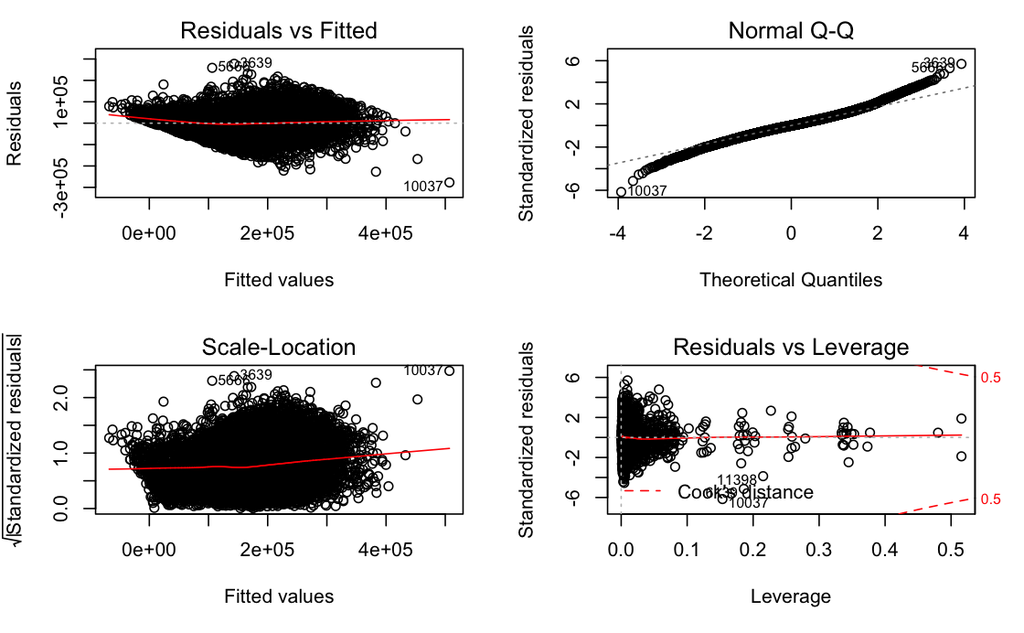

```r
par(mfrow = c(2,2))
plot(lm_clean)
```

```
not plotting observations with leverage one:
  12398
```

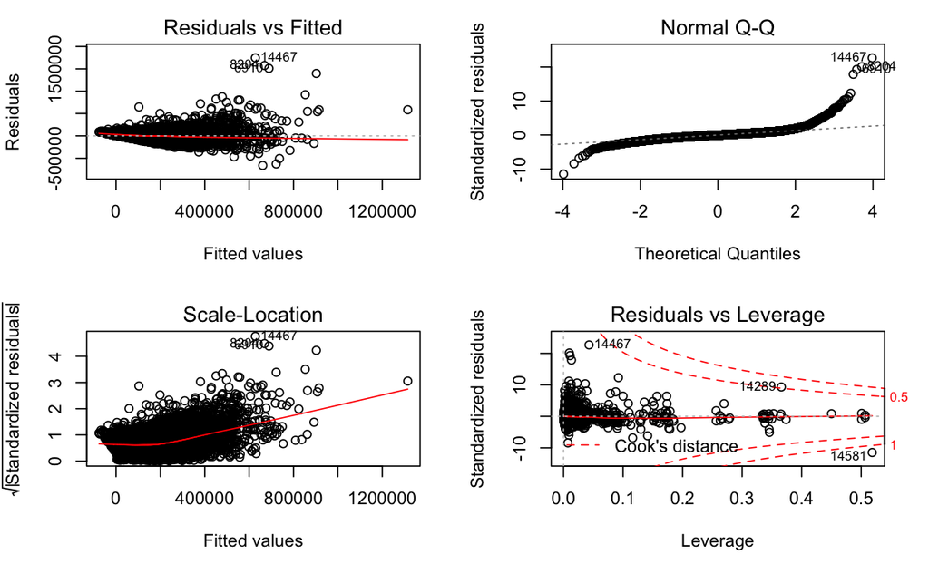

```r
par(mfrow = c(2,2))
plot(lm_raw)
```

#### **5. Subset Analysis**

**Here I test the following:**

1. Is pre and post-corona data significantly different?
   - I test this by testing the significance of a ‘corona’ dummy variable (1 for post-corona and 0 for pre-corona)
2. Are there significant differences in the way key variables (e.g. premium for bedrooms or β<sub>beds_total</sub>) are impacted by the Corona crisis?
   - I follow a method suggested by UCLA’s statistics department which you can read through [**here**](https://stats.idre.ucla.edu/sas/faq/how-can-i-compare-regression-coefficients-across-three-or-more-groups/) if you wish

##### **5.1 Dummy-Variable Regression: Corona = 1**

We see that belonging to the ‘post-corona’ subset is associated on average with a market **price premium of +$26,750**, ceteris parabus. This finding is statistically significant with **p-value < 0.00** under the most controlled model.

```r
summary(lm_corona_test)
```

```
Call:
lm(formula = sold_price ~ post_corona_bi + . - mls_number - school_high -
    school_junior - school_middle - roof_type_shingle_bi - sold_date -
    total_area - corona_crisis, data = data_no_outliers)

Residuals:
    Min      1Q  Median      3Q     Max
-282122  -28410    -127   28419  285225

Coefficients:
                                   Estimate Std. Error t value Pr(>|t|)
(Intercept)                       1.146e+05  5.365e+04   2.136 0.032715 *
post_corona_bi                    2.675e+04  1.522e+03  17.575  < 2e-16 ***
property_typeDUP                 -1.892e+04  2.816e+04  -0.672 0.501674
property_typeOTH                  1.029e+05  2.828e+04   3.639 0.000275 ***
property_typePAT                  3.402e+03  1.056e+04   0.322 0.747305
property_typeSGL                  2.942e+04  3.754e+03   7.837 5.02e-15 ***
property_typeTNH                  1.949e+04  4.931e+03   3.952 7.78e-05 ***
air_conditioningnot_central      -2.834e+04  1.784e+03 -15.885  < 2e-16 ***
appartment_bi                    -7.143e+03  2.081e+04  -0.343 0.731396
patio_bi                          8.529e+03  1.018e+03   8.376  < 2e-16 ***
school_general                    9.670e+03  2.171e+03   4.455 8.49e-06 ***
photo_count                       8.839e+02  6.022e+01  14.679  < 2e-16 ***
pool_bi                           1.175e+04  1.754e+03   6.702 2.15e-11 ***
rear_yard_access_bi              -1.064e+04  3.880e+03  -2.743 0.006091 **
roof_typeother                    3.407e+03  1.789e+03   1.905 0.056828 .
roof_typeshingle                  3.202e+04  2.031e+03  15.768  < 2e-16 ***
roof_typeslate                    1.650e+03  8.158e+03   0.202 0.839677
gas_typeNatural                  -1.440e+05  4.887e+04  -2.947 0.003210 **
gas_typeNone                     -1.436e+05  4.888e+04  -2.938 0.003306 **
gas_typePropane                  -8.036e+04  5.292e+04  -1.519 0.128869
out_building_livable_bi           9.217e+03  1.244e+04   0.741 0.458934
out_building_not_livable_bi      -8.061e+03  1.100e+03  -7.329 2.47e-13 ***
living_area                       6.178e+01  1.556e+00  39.714  < 2e-16 ***
land_acres                        8.981e+02  1.320e+03   0.680 0.496389
appliances_included_bi            2.280e+04  1.343e+03  16.977  < 2e-16 ***
garage_bi                         1.430e+04  1.008e+03  14.193  < 2e-16 ***
conditionExcellent                6.016e+04  6.488e+03   9.272  < 2e-16 ***
conditionFair                    -3.058e+04  9.131e+03  -3.349 0.000813 ***
conditionOther                    2.066e+04  6.665e+03   3.099 0.001946 **
```

[output cut: 48 more lines]

```
city_limit_bi                     9.052e+03  3.407e+03   2.657 0.007893 **
subdivision_bi                    1.019e+04  2.012e+03   5.065 4.14e-07 ***
tennis_court_bi                  -4.177e+04  2.034e+04  -2.054 0.039978 *
termite_contractUnknown          -9.997e+03  5.124e+03  -1.951 0.051077 .
termite_contractYes              -2.259e+02  4.144e+03  -0.055 0.956515
water_typeOther                  -4.896e+03  1.320e+04  -0.371 0.710818
water_typePublic                 -2.841e+03  1.303e+04  -0.218 0.827328
water_typeWell                   -6.071e+01  1.424e+04  -0.004 0.996598
waterfront_bi                     3.316e+04  1.930e+03  17.180  < 2e-16 ***
---
Signif. codes:  0 ‘***’ 0.001 ‘**’ 0.01 ‘*’ 0.05 ‘.’ 0.1 ‘ ’ 1

Residual standard error: 48290 on 11727 degrees of freedom
Multiple R-squared:  0.6855,    Adjusted R-squared:  0.6832
F-statistic: 300.7 on 85 and 11727 DF,  p-value: < 2.2e-16
```

```
not plotting observations with leverage one:
  11243, 11307, 11322, 11352
```

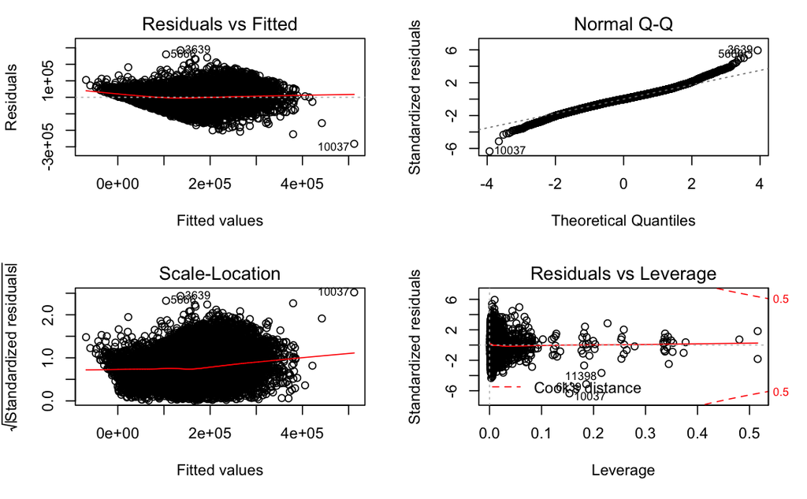

```r
par(mfrow = c(2,2))
plot(lm_corona_test)
```

##### **5.2 Testing Differences of Specific Variables Post and Pre-Corona**

This [**UCLA method**](https://stats.idre.ucla.edu/sas/faq/how-can-i-compare-regression-coefficients-across-three-or-more-groups/) is implimented with the following steps:

1. Run a reduced regression model with only:
   - subset dummy variable (e.g. corona dummy)
   - variable of interest (e.g. beds_total)
   - interaction term: (e.g. corona_dummy*beds_total)

**Note:** The results of the significance level for the interaction term’s beta coefficient tests the null hypothesis: **H<sub>0</sub>: β<sub>pre</sub> = β<sub>post</sub>.**

##### **5.3 Example: Number of Bedrooms**

As you can see, the interaction term (i.e. beds_total*post_corona_bi) is statistically significant at the 0.00 level, suggesting we reject the null hypothesis that β<sub>pre</sub> = β<sub>post</sub>.

This result can also be interpreted as:

> *The average premium for each additional bedroom significantly increased after the outbreak of COVID-19 in March 23, 2020, resulting in an **average premium increase of $8,583 per room**, ceteris parabus.*

> *My (the author’s) hypothesis is that this result is likely driven by an increased demand for an additional bedroom functioning as a **‘home office’** as many workers were legally compelled to work from home, with many of them **never returning** to full-time, on-site working schedules.*

```r
summary(lm_beds_corona_test)
```

```
Call:
lm(formula = sold_price ~ post_corona_bi + beds_total + beds_total *
    post_corona_bi, data = data_no_outliers)

Residuals:
    Min      1Q  Median      3Q     Max
-293588  -49022    1404   44578  335004

Coefficients:
                          Estimate Std. Error t value Pr(>|t|)
(Intercept)                 -12004       4274  -2.809 0.004982 **
post_corona_bi               21178       7297   2.902 0.003711 **
beds_total                   53500       1366  39.151  < 2e-16 ***
post_corona_bi:beds_total     8583       2316   3.706 0.000212 ***
---
Signif. codes:  0 ‘***’ 0.001 ‘**’ 0.01 ‘*’ 0.05 ‘.’ 0.1 ‘ ’ 1

Residual standard error: 74840 on 11809 degrees of freedom
Multiple R-squared:  0.2392,    Adjusted R-squared:  0.239
F-statistic:  1238 on 3 and 11809 DF,  p-value: < 2.2e-16
```

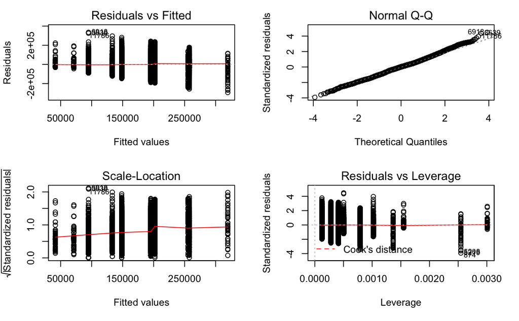

#### **6. Questions for You and Next Steps**

##### **6.1 Questions**

1. Are you in agreement with the current method of comparing beta coefficients across models?
   - If you are, then I will continue by repeating the process across several key variables and with the other subsets we’ve already discussed (e.g. top vs bottom 25th percentile of size, price, etc.)
2. Do you have any suggesions for specific variable transformations in these OLS models (e.g. log(price) )?
   - I will make many transformation for the ML pridition models, but wanted to get your opinion here.
3. Do you have any other extentions or models which could make this analysis ritcher, more robust?
   - Because this ‘core’ portion of the analysis went so well, I’m interested in pushing the limit of academic technicallity for the sake of the paper and the grading process down the road.

##### **6.2 Next Steps**

1. I am about 60% of the way through coding the ML models and will likely make another RMarkdown file like this one for that process as well
2. I am currently collecting specific papers for a literature review and also pulling other ‘soft’ figures about the crisis itself in Louisiana for narrative and context.
3. Once I have completed the ML model and have combined the finding into one, succinct line of analysis, I hope to have a review meeting with you to descuss improvements.

#### **Final Statement**

##### As always, thanks for taking the time to read through this and for your guidence!

##### Sawyer

*End of Document*